# Exercise Set 2: Solutions

ETC3550: 2018

# fpp2.10, ex4

> Create time plots of the following time series: `bicoal`, `chicken`, `dole`, `usdeaths`, `lynx`, `goog`, `writing`, `fancy`, `a10`, `h02`. + Use `help()` to find out about the data in each series. + For the `goog` plot, modify the axis labels and title.

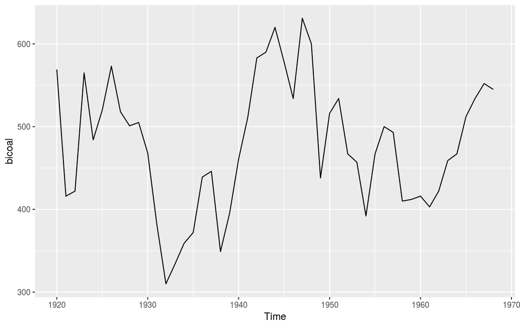

```r
library(fpp2)
autoplot(bicoal)
```

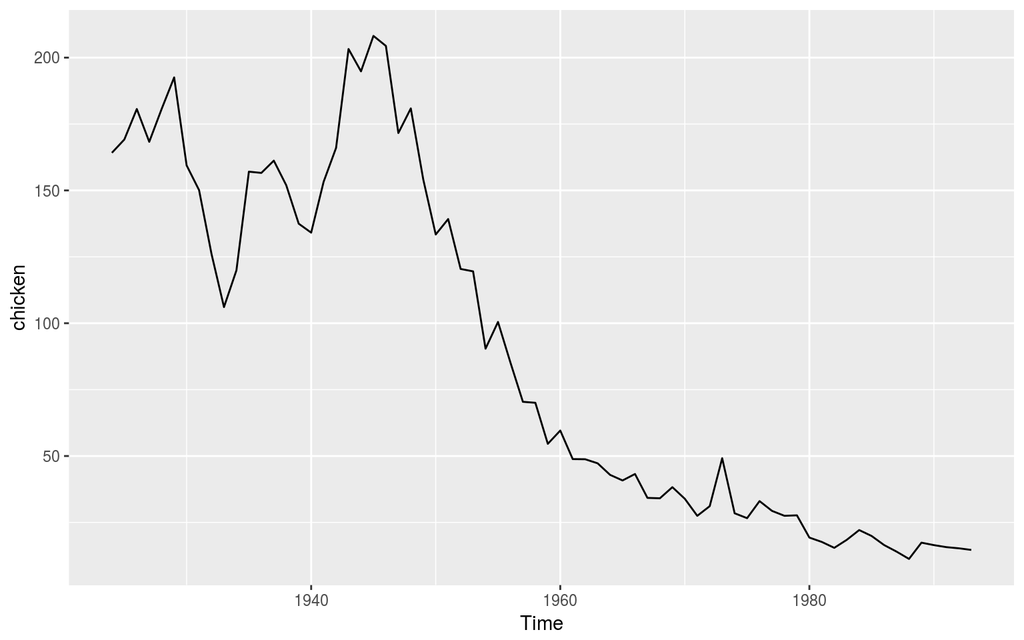

```r
autoplot(chicken)
```

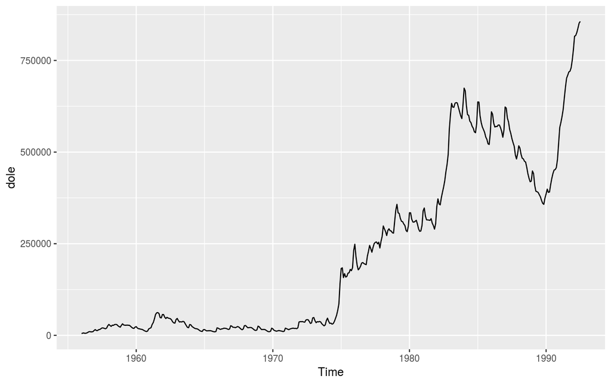

```r
autoplot(dole)
```

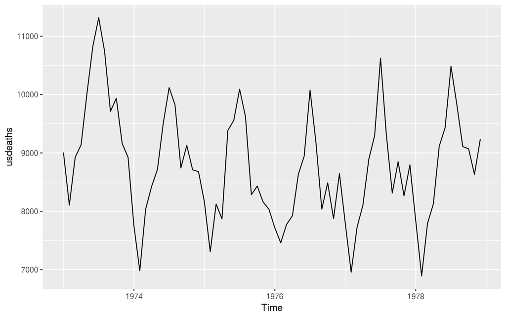

```r
autoplot(usdeaths)
```

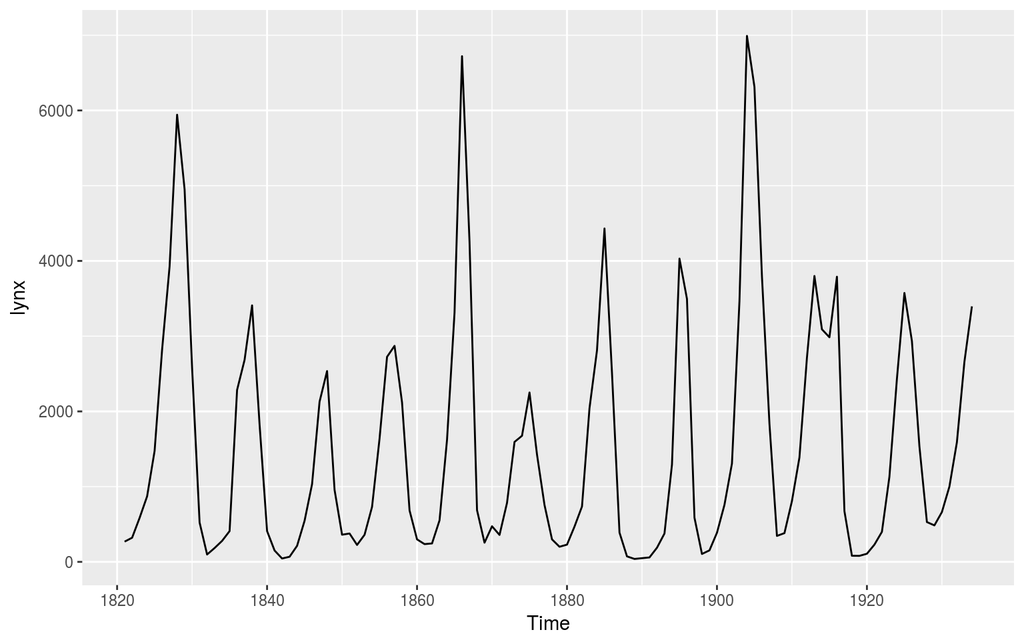

```r
autoplot(lynx)
```

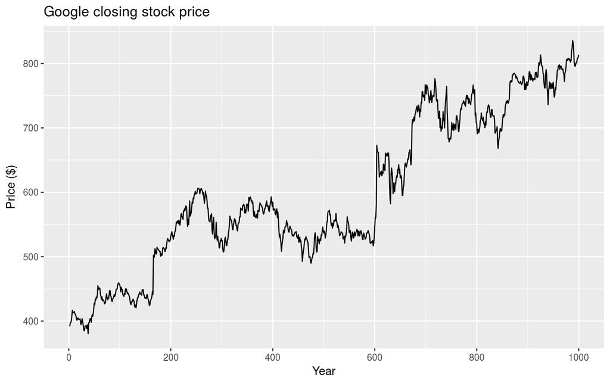

```r
autoplot(goog) +
  xlab("Year") + ylab("Price ($)") +
  ggtitle("Google closing stock price")
```

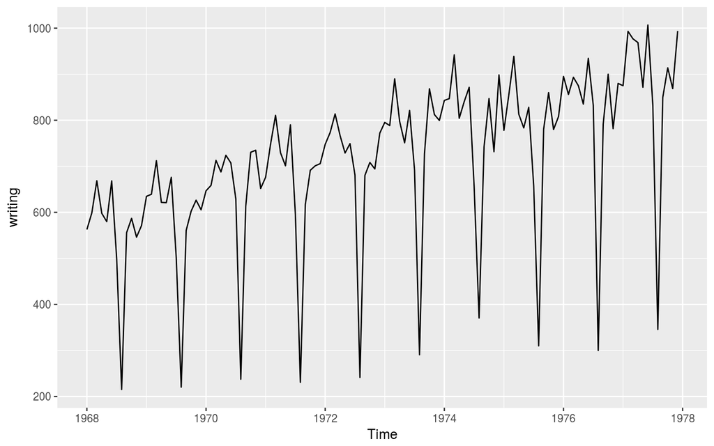

```r
autoplot(writing)
```

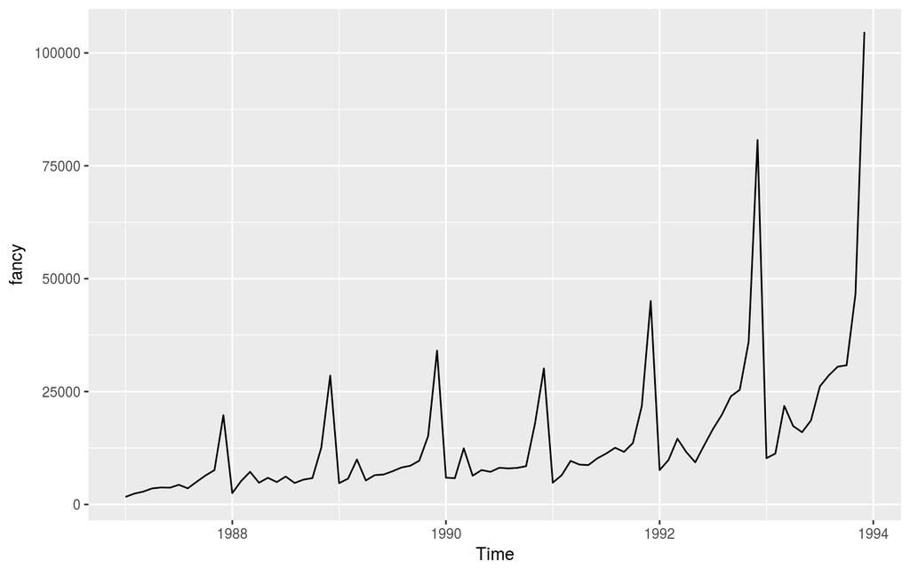

```r
autoplot(fancy)
```

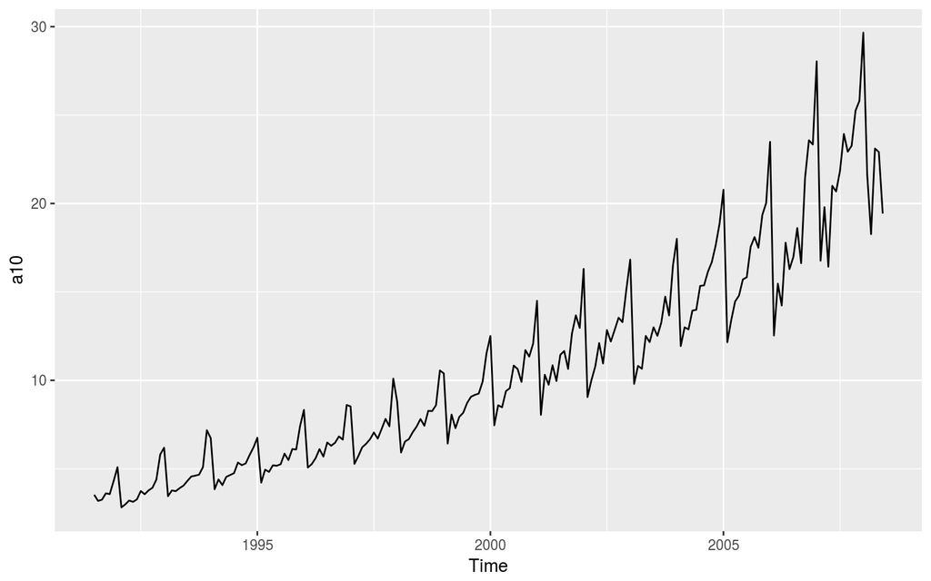

```r
autoplot(a10)
```

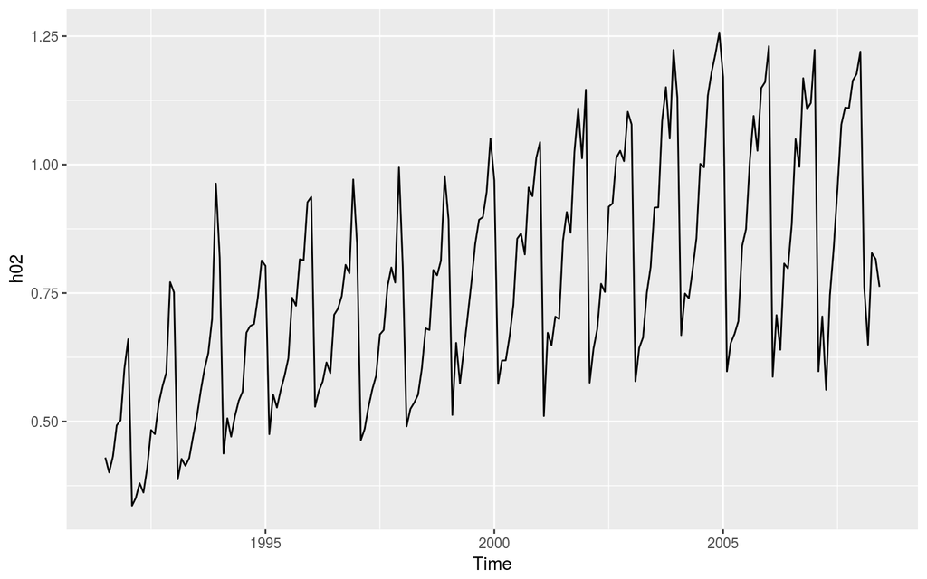

```r
autoplot(h02)
```

# fpp2.10, ex5

> Use the `ggseasonplot` and `ggsubseriesplot` functions to explore the seasonal patterns in the following time series: `writing`, `fancy`, `a10`, `h02`.
> - What can you say about the seasonal patterns?
> - Can you identify any unusual years?

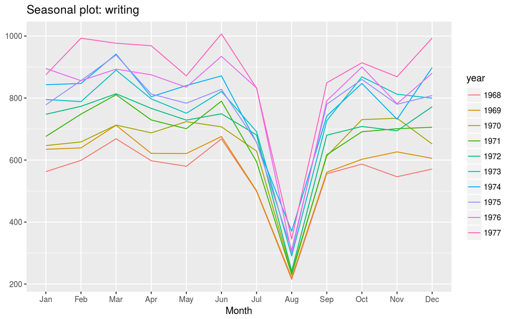

```r
ggseasonplot(writing)
```

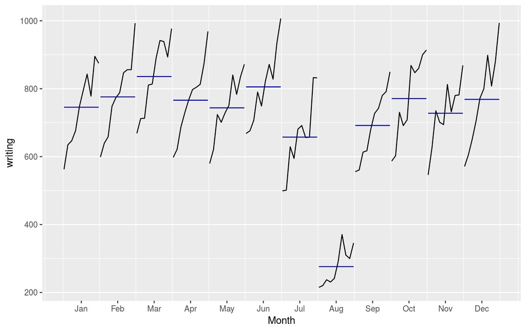

```r
ggsubseriesplot(writing)
```

- August is very low compared to other months (a summer vacation effect in France)
- Otherwise weak seasonality
- No obviously unusual years

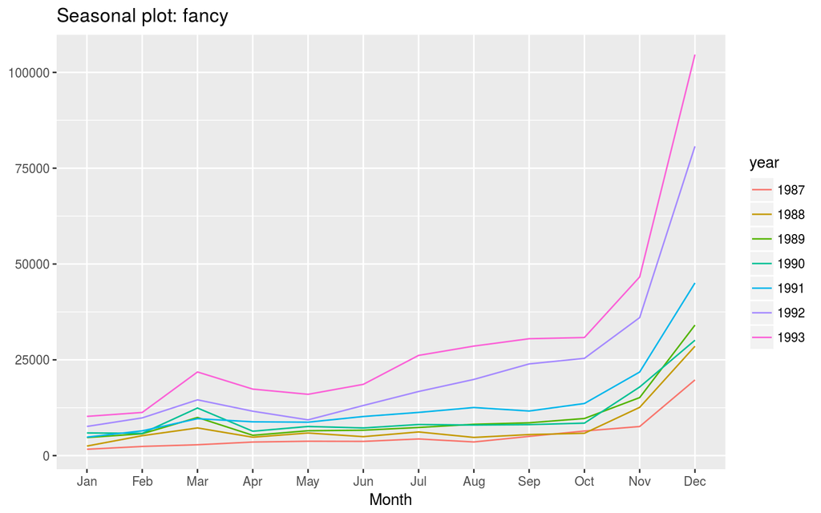

```r
ggseasonplot(fancy)
```

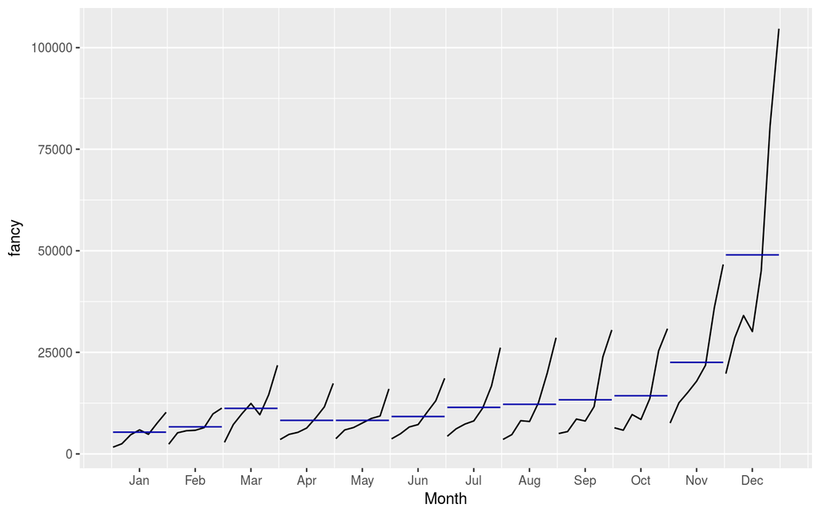

```r
ggsubseriesplot(fancy)
```

December is much higher than the other months, presumably due to summer holidays in Queensland, or possibly Christmas. The last few years show much higher sales than previous years, but this is probably just due to the exponential trend in the data.

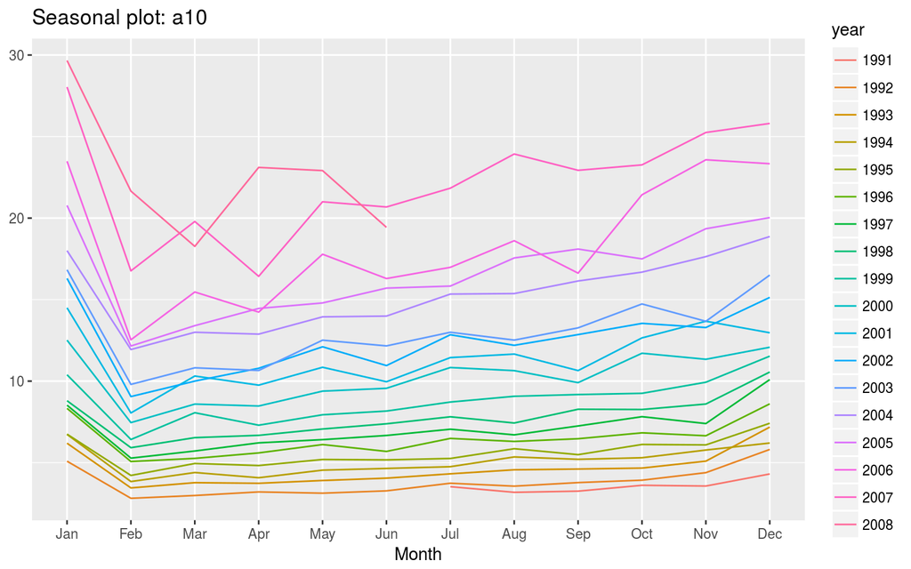

```r
ggseasonplot(a10)
```

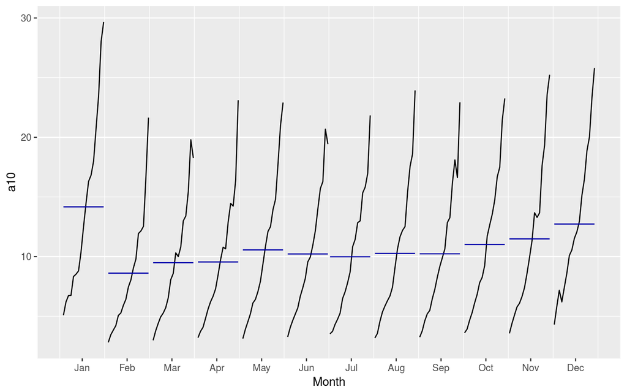

```r
ggsubseriesplot(a10)
```

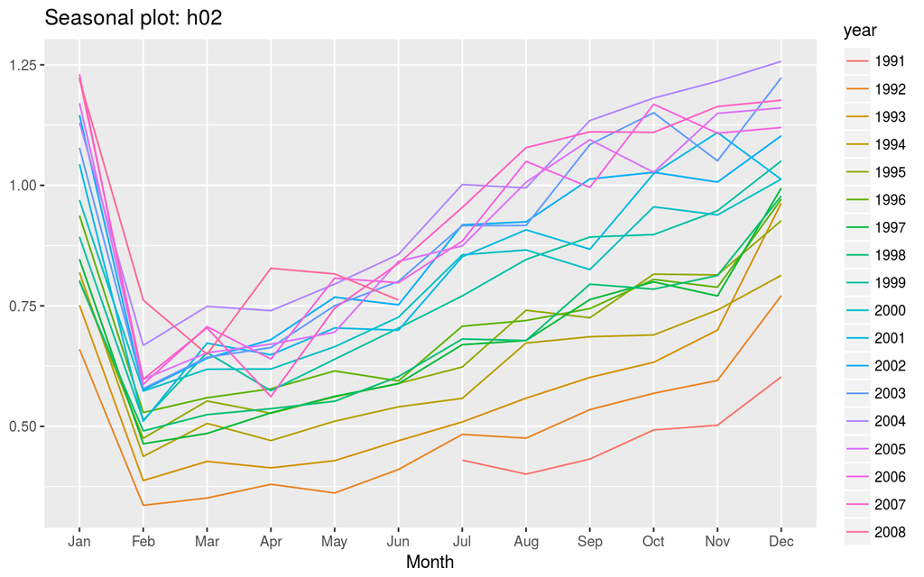

```r
ggseasonplot(h02)
```

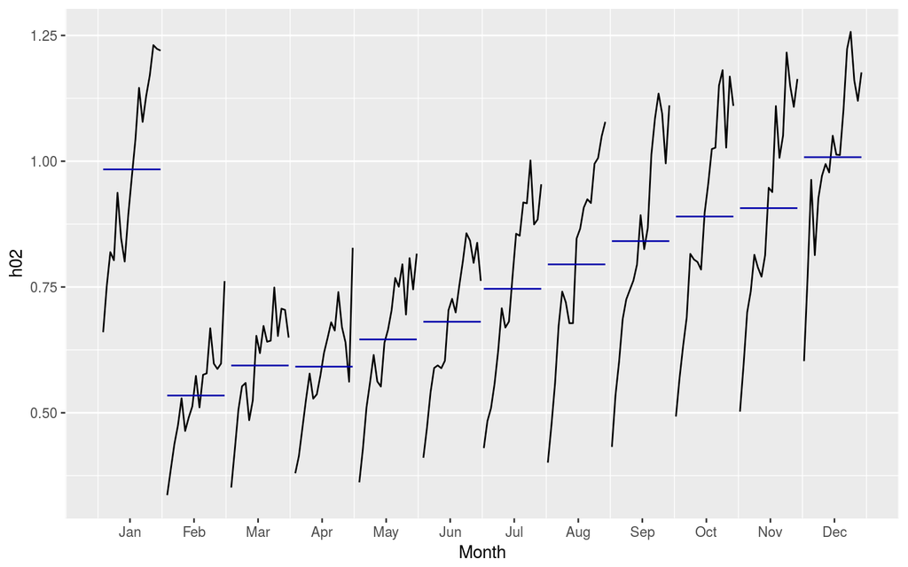

```r
ggsubseriesplot(h02)
```

- seasonality jumps in January, falls in February, then slowly increases through the year.
- Feb-Mar-Apr pattern of down-up-down probably due to month lengths
- 2008 reverses the pattern

# fpp2.10, ex9

> The `pigs` data shows the monthly total number of pigs slaughtered in Victoria, Australia, from Jan 1980 to Aug 1995. Use `mypigs <- window(pigs, start=1990)` to select the data starting from 1990. Use `autoplot` and `ggAcf` for `mypigs` series and compare these to white noise plots.

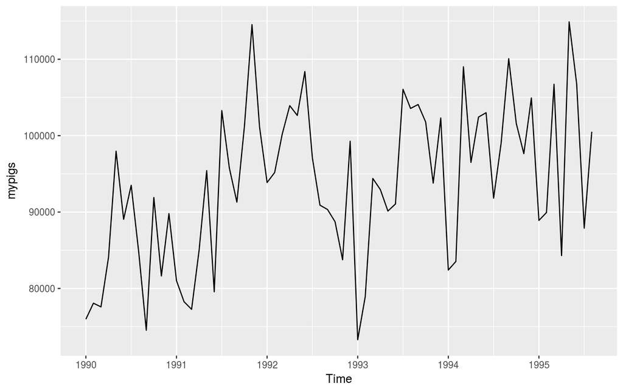

```r
mypigs <- window(pigs, start=1990)
autoplot(mypigs)
```

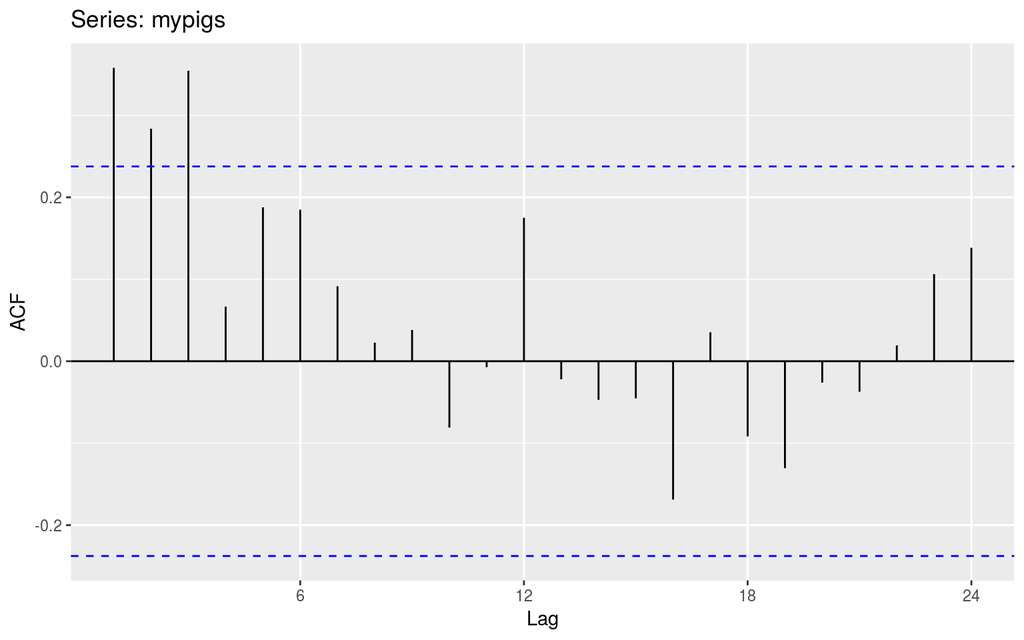

```r
ggAcf(mypigs)
```

The time plot appears to have a slight upward trend, and there is some significant autocorrelation in the first three lags. So this data set is significantly different from white noise.

# fpp2.10, ex10

> `dj` contains 292 consecutive trading days of the Dow Jones Index. Use `ddj <- diff(dj)` to compute the daily changes in the index. Plot `ddj` and its ACF. Do the changes in the Dow Jones Index look like white noise?

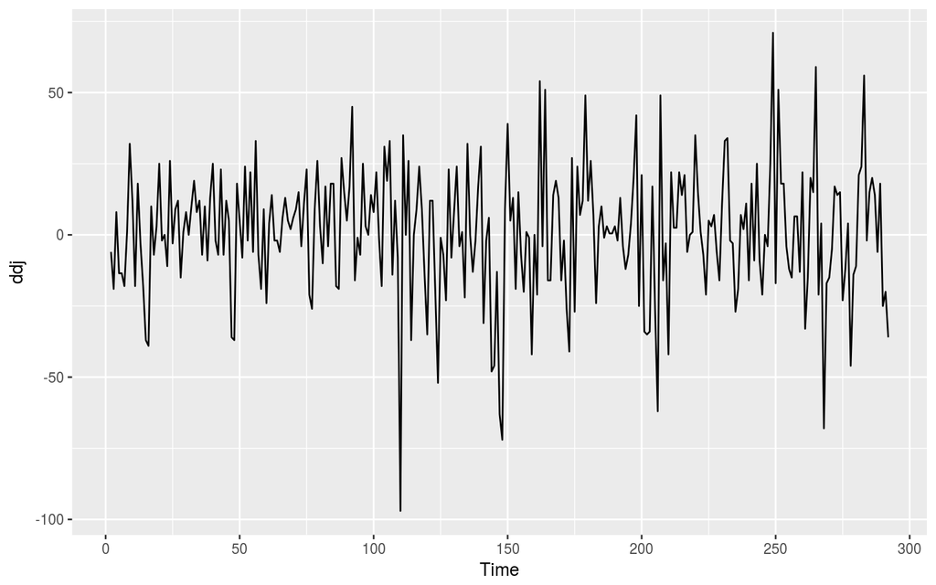

```r
ddj <- diff(dj)
autoplot(ddj)
```

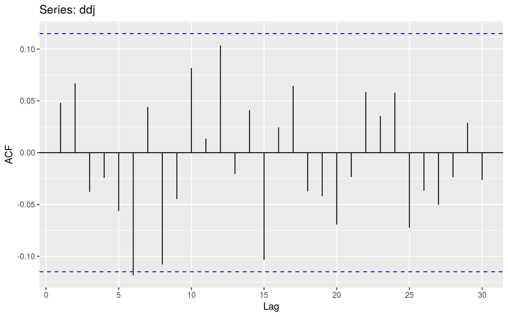

```r
ggAcf(ddj, lag.max=30)
```

The ACF has few spikes outside the limits (1 out of 30). We expect about 5% to lie outside the limits, so this is within expectation, and they do not lie far outside the critical values. So this differenced series looks like white noise.

# 2

> You can compute the daily changes in the Google stock price using

> ```r
> dgoog <- diff(goog)
> ```

> Does `dgoog` look like white noise?

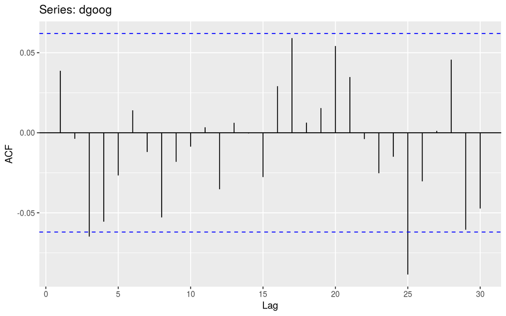

```r
dgoog <- diff(goog)
ggAcf(dgoog, lag.max=30)
```

# 3

> In Assignment 2, it was suggested that you use the following code to read your data.

> ```
> id <- "26873333"
> retaildata <- read.csv("retail.csv", header=TRUE)
> colnames(retaildata) <- retaildata[1,]
> mytimeseries <- retaildata[[id]][-1]
> mytimeseries <- ts(as.numeric(mytimeseries), frequency=12, start=c(1982,4))
> ```

> Turn this code into a function which takes the id as an input, and returns the required time series from the data set.

```r
get_retail <- function(id)
{
  retaildata <- read.csv("retail.csv", header=TRUE)
  colnames(retaildata) <- retaildata[1,]
  mytimeseries <- retaildata[[id]][-1]
  mytimeseries <- ts(as.numeric(mytimeseries), frequency=12, start=c(1982,4))
  return(mytimeseries)
}
```